# Assignment 2 - Image filters

The following graphics shows exemplary the mathematical operations of the convolution. The filter matrix **H** is shifted over the input image **I**. The values 'under' the filter matrix are multiplicated with the corresponding values in **H**, summed up and writen to the result **J**. The target position is usually the position under the center of **H**.

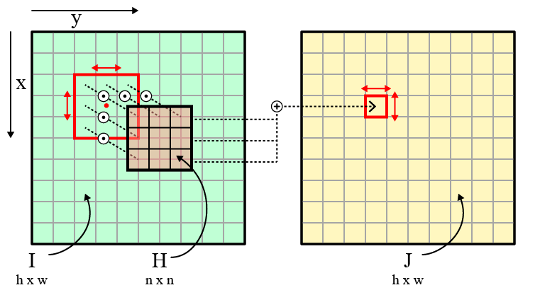

- **I**: Image to convolve.
- **H**: filter matrix to convolve the image with.
- **J**: Result of the convolution.

At the image boundaries, the filter mask will be outside the image. So we need to extend the image boundaries, which is called "padding".

### Dependencies

Please run the following block first if you have installed the necessary dependencies.

```python
!pip install numpy
!pip install opencv-contrib-python-headless==4.7.0.68
!pip install matplotlib
!pip install scikit-image
```

### Import the 3rd party libraries

```python
# Numpy offers comprehensive mathematical functions in Python
import numpy as np

# OpenCV provides a optimized tools for Computer Vision.
import cv2 as cv

# Matplotlib is a library for creating visualizations in Python.
from matplotlib import pyplot as plt

#Scikit-image offers a random noise method
from skimage.util import random_noise
```

### Task 1: Convolution

In this task you will realize padding and convolution:

Steps:

1. padding the given src_img using different image boundaries (zero, wrap, clamp, mirror), padding width = 20
2. convolve the given kernel with src_mat

Variables:

1. `zero_padding` : extended image using zero padding
2. `wrap_padding` : extended image using wrap padding
3. `clamp_padding` : extended image using clamp padding
4. `mirror_padding` : extended image using mirror padding
5. `conv_mat` : convolution result

Hints:

1. Function [cv.copyMakeBorder](https://docs.opencv.org/3.4/d2/de8/group__core__array.html#ga2ac1049c2c3dd25c2b41bffe17658a36) to padding
2. Function [cv.filter2D](https://docs.opencv.org/4.x/d4/d86/group__imgproc__filter.html#ga27c049795ce870216ddfb366086b5a04) to convolve a kernel with an image. Notice that `cv.filter2D` will automatically create padding according to `borderType`(See Hint 3), you don't need to do padding before you call.
3. The 7th parameter of `cv.filter2D` is `borderType` defines the padding methods, seeing [BorderTypes](https://docs.opencv.org/4.x/d2/de8/group__core__array.html#ga209f2f4869e304c82d07739337eae7c5) to know about basic type of padding in OpenCV, default as `BORDER_CONSTANT`

#### Quiz 1:

**Which borderTypes will provide continous grey values at the border? and which may have strong grey value changes?**

```python
src_img = cv.imread('example/house.jpg',cv.IMREAD_GRAYSCALE)

kernel =  np.array([[1,3,1],[-2,-1,-2],[1,3,1]])

### BEGIN SOLUTION

### END SOLUTION

plt.figure(figsize=(16, 8), dpi=96)
plt.subplot(1,6,1)
plt.title("src img")
plt.imshow(src_img, cmap='gray')
plt.axis ('off')
plt.subplot(1,6,2)
plt.title("zero padding")
plt.imshow(zero_padding, cmap=plt.cm.gray)
plt.axis ('off')
plt.subplot(1,6,3)
plt.title("wrap padding")
plt.imshow(wrap_padding, cmap=plt.cm.gray)
plt.axis ('off')
plt.subplot(1,6,4)
plt.title("clamp padding")
plt.imshow(clamp_padding, cmap=plt.cm.gray)
plt.axis ('off')
plt.subplot(1,6,5)
plt.title("mirror padding")
plt.imshow(mirror_padding, cmap=plt.cm.gray)
plt.axis ('off')
plt.subplot(1,6,6)
plt.title("conv mat")
plt.imshow(conv_mat, cmap='gray')
plt.axis ('off')
plt.show()
```

[output not shown]

```python
def public_test1():
    try:
        zero_padding
    except NameError:
        print("[Error] Variable zero_padding is not defined")
        return False

    try:
        wrap_padding
    except NameError:
        print("[Error] Variable wrap_padding is not defined")
        return False

    try:
        clamp_padding
    except NameError:
        print("[Error] Variable clamp_padding is not defined")
        return False

    try:
        mirror_padding
    except NameError:
        print("[Error] Variable mirror_padding is not defined")
        return False

    try:
        conv_mat
    except NameError:
        print("[Error] Variable conv_mat is not defined")
        return False
    return True

assert public_test1()
```

### Task 2: BOX Filter, Gaussian Filter and median Filter

In this task you will create kernels of different filters and apply it on the given images:

Variables:

1. `box_kernel` : kernel of box filter
2. `gaussian_kernel` : kernel of gaussian filter
3. `box_result` : convolution result using box filter
4. `gaussian_result` : convolution result using gaussian filter
5. `median_result` : convolution result using median filter

Hints:

1. Function [cv.getGaussianKernel](https://docs.opencv.org/4.x/d4/d86/group__imgproc__filter.html#gac05a120c1ae92a6060dd0db190a61afa) to create gaussian kernel
2. Function [cv.sepFilter2D](https://docs.opencv.org/4.x/d4/d86/group__imgproc__filter.html#ga910e29ff7d7b105057d1625a4bf6318d) to apply gaussian filter
3. Function [cv.medianBlur](https://docs.opencv.org/4.x/d4/d86/group__imgproc__filter.html#ga564869aa33e58769b4469101aac458f9) to use median filter

#### Quiz 2:

**Please try to characterize the images after applying different filters.**

```python
gaussian_noise_img = (255*random_noise(src_img,mode='gaussian')).astype(np.uint8)
saltNpepper_noise_img = (255*random_noise(src_img,mode='s&p')).astype(np.uint8)

### BEGIN SOLUTION

### END SOLUTION
plt.figure(figsize=(4, 7), dpi=109)
plt.subplot(3,2,1)
plt.imshow(gaussian_noise_img,cmap='gray')
plt.title("gaussian noise")
plt.axis ('off')
plt.subplot(3,2,2)
plt.imshow(box_result,cmap='gray')
plt.title("box filter")
plt.axis ('off')
plt.subplot(3,2,3)
plt.imshow(gaussian_noise_img,cmap='gray')
plt.title("gaussian noise")
plt.axis ('off')
plt.subplot(3,2,4)
plt.imshow(gaussian_result,cmap='gray')
plt.title("gaussian filter")
plt.axis ('off')
plt.subplot(3,2,5)
plt.imshow(saltNpepper_noise_img,cmap='gray')
plt.title("salt&pepper noise")
plt.axis ('off')
plt.subplot(3,2,6)
plt.imshow(median_result,cmap='gray')
plt.title("median filter")
plt.axis ('off')
plt.show()
```

[output not shown]

```python
def public_test2():
    try:
        box_kernel
    except NameError:
        print("[Error] Variable box_kernel is not defined.")
        return False

    try:
        box_kernel.shape == (5,5)
    except:
        print("[Error] The shape of box_kernel is wrong.")
        return False

    try:
        gaussian_kernel
    except NameError:
        print("[Error] Variable gaussian_kernel is not defined")
        return False

    try:
        gaussian_kernel.shape == (5,1)
    except:
        print("[Error] The shape of gaussian_kernel is wrong.")
        return False

    try:
        box_result
    except NameError:
        print("[Error] Variable box_result is not defined")
        return False

    try:
        gaussian_result
    except NameError:
        print("[Error] Variable gaussian_result is not defined")
        return False

    try:
        median_result
    except NameError:
        print("[Error] Variable median_result is not defined")
        return False

    return True

assert public_test2()
```

### Task 3:Sobel Filter

In this task you will create kernels of sobel filters and apply it on the aboved `src_img`:

Steps:

1. create the kernel of 3x3 sobel filter in x and y direction separately
2. apply them separately to calculate x and y gradient
3. calculate the magnitude and the direction of the gradient

Variables:

1. `sobel_x_kernel` : kernel of sobel filter in x direction
2. `sobel_y_kernel` : kernel of sobel filter in y direction
3. `gradient_x` : gradient of `src_img` in x direction
4. `gradient_y` : gradient of `src_img` in y direction
5. `magnitude` : magnitude of gradient
6. `direction` : direction of gradient

Hints:

1. Function [cv.filter2D](https://docs.opencv.org/4.x/d4/d86/group__imgproc__filter.html#ga27c049795ce870216ddfb366086b5a04) to convolve a kernel with an image.
2. The 2nd parameter of function `cv.filter2D` here should be `cv.CV_64F` to prevent a bug.

#### Quiz 3:

**Please explain why we need to calculate the magnitude and direction for the gradient images?**

```python
### BEGIN SOLUTION

### END SOLUTION


direction = cv.normalize(direction,None,0,2*np.pi,cv.NORM_MINMAX)

plt.subplot(2,2,1)
plt.imshow(gradient_x,cmap='gray')
plt.axis('off')
plt.subplot(2,2,2)
plt.imshow(magnitude,cmap='Greys')
plt.axis('off')
plt.subplot(2,2,3)
plt.imshow(gradient_y,cmap='gray')
plt.axis('off')
plt.subplot(2,2,4)
plt.imshow(direction,cmap='turbo')
plt.axis('off')
plt.show()
```

[output not shown]

```python
def public_test3():
    try:
        sobel_x_kernel
    except NameError:
        print("[Error] Variable sobel_x_kernel is not defined")
        return False

    try:
        sobel_x_kernel.shape == (3,3)
    except:
        print("[Error] The shape of sobel_x_kernel is wrong.")
        return False

    try:
        sobel_y_kernel
    except NameError:
        print("[Error] Variable sobel_y_kernel is not defined")
        return False

    try:
        sobel_y_kernel.shape == (3,3)
    except:
        print("[Error] The shape of sobel_y_kernel is wrong.")
        return False

    try:
        gradient_x
    except NameError:
        print("[Error] Variable gradient_x is not defined")
        return False

    try:
        gradient_y
    except NameError:
        print("[Error] Variable gradient_y is not defined")
        return False

    try:
        magnitude
    except NameError:
        print("[Error] Variable magnitude is not defined")
        return False

    try:
        direction
    except NameError:
        print("[Error] Variable direction is not defined")
        return False

    return True

assert public_test3()
```

### Task 4:Laplacian Filter

In this task you will create kernels of laplacian filters and apply it on the aboved `src_img`:

Steps:

1. create the kernel of 3x3 laplacian filter (4 neighbor) in x and y direction separately
2. apply them separately to calculate gradient
3. repeat step 1 and 2 using 3x3 laplacian filter (8 neighbor)

Variables:

1. `laplacian_kernel_4` : kernel of laplacian filter
2. `gradient_4` : gradient using 4 neighbor kernel of `src_img`
3. `laplacian_kernel_8` : kernel of laplacian filter
4. `gradient_8` : gradient using 8 neighbor kernel of `src_img`

Hints:

1. Function [cv.filter2D](https://docs.opencv.org/4.x/d4/d86/group__imgproc__filter.html#ga27c049795ce870216ddfb366086b5a04) to convolve a kernel with an image.

### Quiz 4:

**Please explain the difference between directly applying laplacian operator and applying laplacian operator on an image after smoothing.**

```python
### BEGIN SOLUTION

### END SOLUTION

plt.subplot(1,2,1)
plt.imshow(cv.convertScaleAbs(gradient_4),cmap='gray')
plt.axis('off')
plt.subplot(1,2,2)
plt.imshow(cv.convertScaleAbs(gradient_8),cmap='gray')
plt.axis('off')
plt.show()
```

[output not shown]

```python
def public_test4():
    try:
        laplacian_kernel_4
    except NameError:
        print("[Error] Variable laplacian_kernel_4 is not defined")
        return False

    try:
        laplacian_kernel_4.shape == (3,3)
    except:
        print("[Error] The shape of laplacian_kernel_4 is wrong.")
        return False

    try:
        laplacian_kernel_8
    except NameError:
        print("[Error] Variable laplacian_kernel_8 is not defined")
        return False

    try:
        laplacian_kernel_8.shape == (3,3)
    except:
        print("[Error] The shape of laplacian_kernel_8 is wrong.")
        return False

    try:
        gradient_4
    except NameError:
        print("[Error] Variable gradient_4 is not defined")
        return False

    try:
        gradient_8
    except NameError:
        print("[Error] Variable gradient_8 is not defined")
        return False

    return True

assert public_test4()
```